# wine_report.Rmd

install.packages(“here”)

#DATA

This dataset is affiliated with red and white variants of the Portuguese “Vinho Verde” wine provided by UCIML. variables provided from the dataset can be shown in this table:

[output not shown]

Fixed acidity acids involved with wine fixed or nonvolatile  
Volatile acidity amount of acetic acid in wine, which at high levels can lead to an unpleasant taste  
Citric acid citric acid adds freshness and flavor. Residual sugar the amount of sugar left after fermentation Chlorides amount of salt in wine  
Free sulfur dioxide the free form of SO2  
Total sulfur dioxide the amount of free and bound forms of S02  
Density depends on the percent of alcohol and sugar  
pH shows how acidic or basic a wine is  
Sulphate additive contributes to S02 & acts as an antimicrobial Alcohol percentage of alcohol by volume  
Quality a score between 0 and 10

#EDA

```r
#We took a look into our data using
str(wineqc)
```

```
## spec_tbl_df [1,599 × 12] (S3: spec_tbl_df/tbl_df/tbl/data.frame)
##  $ fixed_acidity       : num [1:1599] 7.4 7.8 7.8 11.2 7.4 7.4 7.9 7.3 7.8 7.5 ...
##  $ volatile_acidity    : num [1:1599] 0.7 0.88 0.76 0.28 0.7 0.66 0.6 0.65 0.58 0.5 ...
##  $ citric_acid         : num [1:1599] 0 0 0.04 0.56 0 0 0.06 0 0.02 0.36 ...
##  $ residual_sugar      : num [1:1599] 1.9 2.6 2.3 1.9 1.9 1.8 1.6 1.2 2 6.1 ...
##  $ chlorides           : num [1:1599] 0.076 0.098 0.092 0.075 0.076 0.075 0.069 0.065 0.073 0.071 ...
##  $ free_sulfur_dioxide : num [1:1599] 11 25 15 17 11 13 15 15 9 17 ...
##  $ total_sulfur_dioxide: num [1:1599] 34 67 54 60 34 40 59 21 18 102 ...
##  $ density             : num [1:1599] 0.998 0.997 0.997 0.998 0.998 ...
##  $ ph                  : num [1:1599] 3.51 3.2 3.26 3.16 3.51 3.51 3.3 3.39 3.36 3.35 ...
##  $ sulphates           : num [1:1599] 0.56 0.68 0.65 0.58 0.56 0.56 0.46 0.47 0.57 0.8 ...
##  $ alcohol             : num [1:1599] 9.4 9.8 9.8 9.8 9.4 9.4 9.4 10 9.5 10.5 ...
##  $ quality             : num [1:1599] 5 5 5 6 5 5 5 7 7 5 ...
##  - attr(*, "spec")=
##   .. cols(
##   ..   `fixed acidity` = col_double(),
##   ..   `volatile acidity` = col_double(),
##   ..   `citric acid` = col_double(),
##   ..   `residual sugar` = col_double(),
##   ..   chlorides = col_double(),
##   ..   `free sulfur dioxide` = col_double(),
##   ..   `total sulfur dioxide` = col_double(),
##   ..   density = col_double(),
##   ..   pH = col_double(),
##   ..   sulphates = col_double(),
##   ..   alcohol = col_double(),
##   ..   quality = col_double()
##   .. )
##  - attr(*, "problems")=<externalptr>
```

```r
summary(wineqc)
```

```
##  fixed_acidity   volatile_acidity  citric_acid    residual_sugar
##  Min.   : 4.60   Min.   :0.1200   Min.   :0.000   Min.   : 0.900
##  1st Qu.: 7.10   1st Qu.:0.3900   1st Qu.:0.090   1st Qu.: 1.900
##  Median : 7.90   Median :0.5200   Median :0.260   Median : 2.200
##  Mean   : 8.32   Mean   :0.5278   Mean   :0.271   Mean   : 2.539
##  3rd Qu.: 9.20   3rd Qu.:0.6400   3rd Qu.:0.420   3rd Qu.: 2.600
##  Max.   :15.90   Max.   :1.5800   Max.   :1.000   Max.   :15.500
##    chlorides       free_sulfur_dioxide total_sulfur_dioxide    density
##  Min.   :0.01200   Min.   : 1.00       Min.   :  6.00       Min.   :0.9901
##  1st Qu.:0.07000   1st Qu.: 7.00       1st Qu.: 22.00       1st Qu.:0.9956
##  Median :0.07900   Median :14.00       Median : 38.00       Median :0.9968
##  Mean   :0.08747   Mean   :15.87       Mean   : 46.47       Mean   :0.9967
##  3rd Qu.:0.09000   3rd Qu.:21.00       3rd Qu.: 62.00       3rd Qu.:0.9978
##  Max.   :0.61100   Max.   :72.00       Max.   :289.00       Max.   :1.0037
##        ph          sulphates         alcohol         quality
##  Min.   :2.740   Min.   :0.3300   Min.   : 8.40   Min.   :3.000
##  1st Qu.:3.210   1st Qu.:0.5500   1st Qu.: 9.50   1st Qu.:5.000
##  Median :3.310   Median :0.6200   Median :10.20   Median :6.000
##  Mean   :3.311   Mean   :0.6581   Mean   :10.42   Mean   :5.636
##  3rd Qu.:3.400   3rd Qu.:0.7300   3rd Qu.:11.10   3rd Qu.:6.000
##  Max.   :4.010   Max.   :2.0000   Max.   :14.90   Max.   :8.000
```

```r
length(wineqc)
```

```
## [1] 12
```

```r
dim(wineqc)
```

```
## [1] 1599   12
```

```r
names(wineqc)
```

```
##  [1] "fixed_acidity"        "volatile_acidity"     "citric_acid"
##  [4] "residual_sugar"       "chlorides"            "free_sulfur_dioxide"
##  [7] "total_sulfur_dioxide" "density"              "ph"
## [10] "sulphates"            "alcohol"              "quality"
```

```r
summary(wineqc$quality)
```

```
##    Min. 1st Qu.  Median    Mean 3rd Qu.    Max.
##   3.000   5.000   6.000   5.636   6.000   8.000
```

```r
table(wineqc$quality)
```

```
##
##   3   4   5   6   7   8
##  10  53 681 638 199  18
```

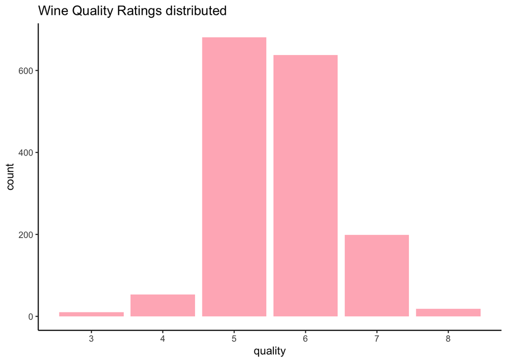

```r
#For quality distirbution
ggplot(wineqc,aes(x=quality))+geom_bar(stat = "count",position = "dodge", fill = "light pink")+
  scale_x_continuous(breaks = seq(3,8,1))+
  ggtitle("Wine Quality Ratings distributed")+
  theme_classic()
```

we can see that majority of the quality is around 5-6. Around 82%

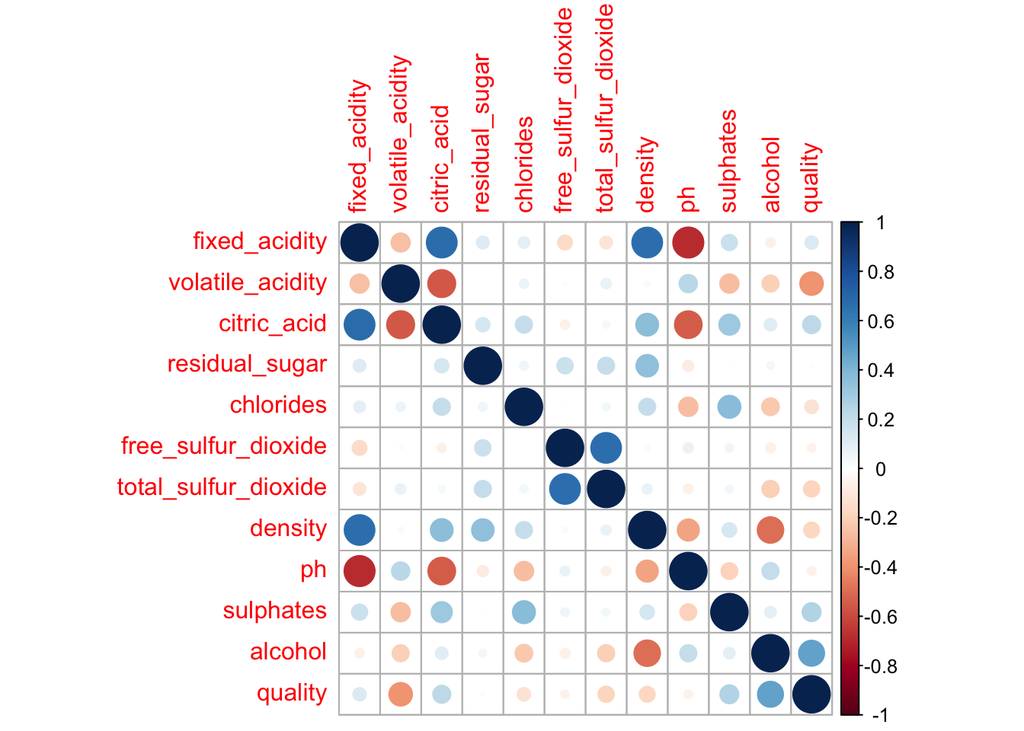

```r
#for the coralation
wine = cor(wineqc)
corrplot(wine)
```

```r
#As the plot offers, alcohol has the most robust correlation with wine quality.
```

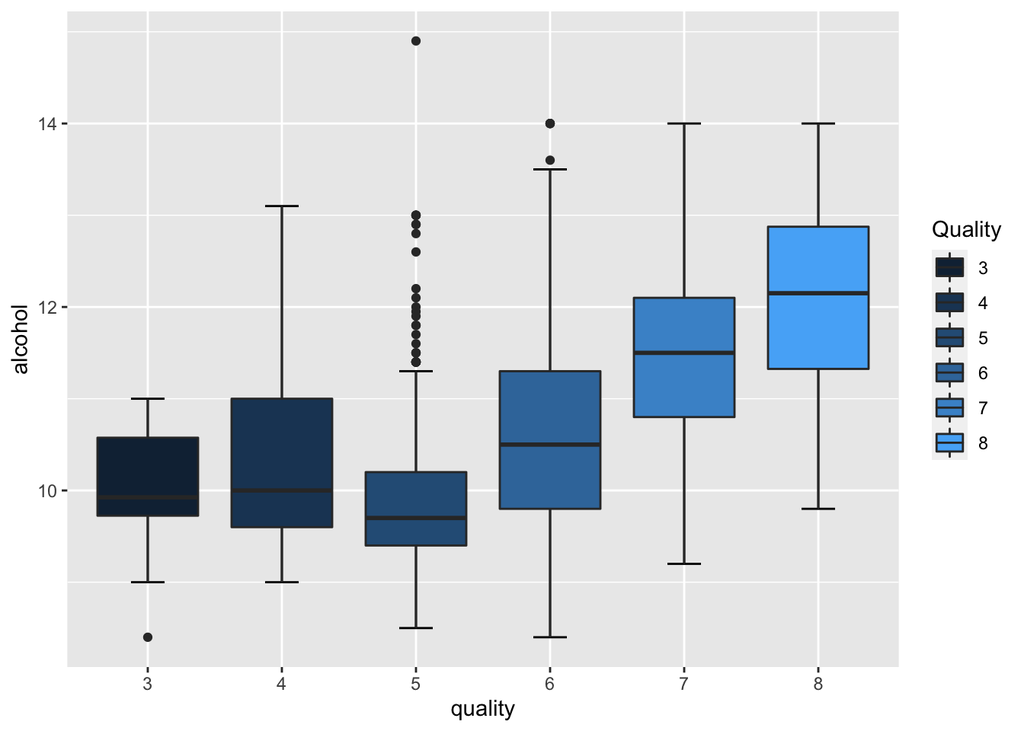

```r
#alcohol
ggplot(wineqc, aes(x = factor(quality), y =alcohol, fill = quality)) +
  stat_boxplot(geom = "errorbar", width = 0.25) +
  geom_boxplot() +
  guides(fill = guide_legend(title = "Quality"))+ xlab("quality")
```

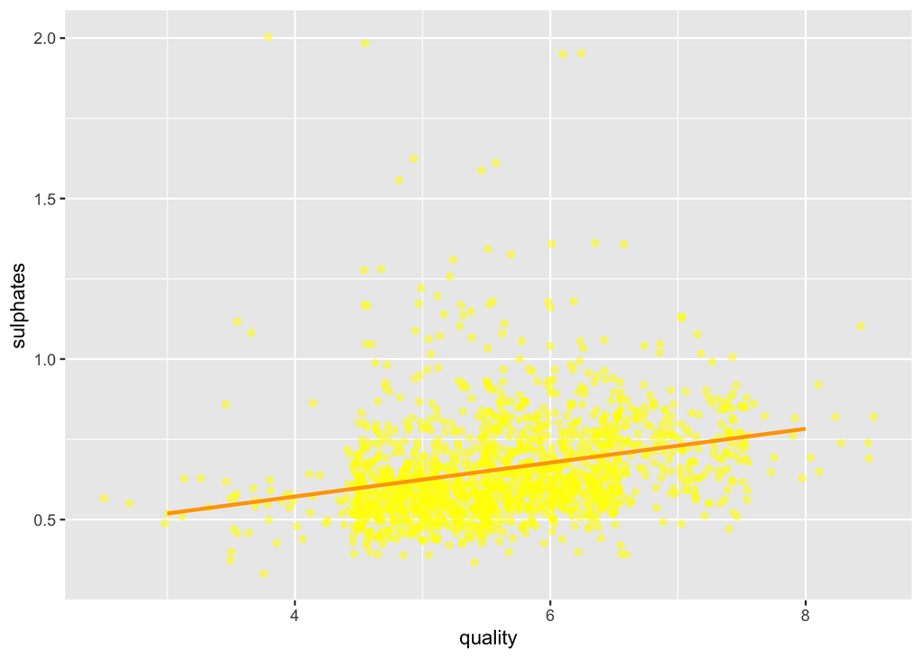

```r
ggplot(wineqc, aes(quality, sulphates)) +
  geom_jitter(width = 0.55, alpha = 0.5, colour = "yellow") +
  geom_smooth(method=lm, se=FALSE, colour = "orange")
```

we can see how sulphate affects the quality

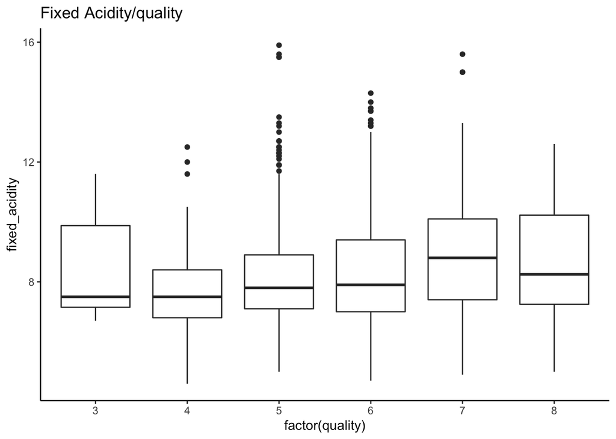

```r
wineqc%>%
  ggplot(aes(factor(quality), `fixed_acidity`, group=quality))+geom_boxplot()+ggtitle("Fixed Acidity/quality")+theme_classic()
```

```r
#how fixed acidity has an affect on quality
```

how fixed acidity has an affect on quality

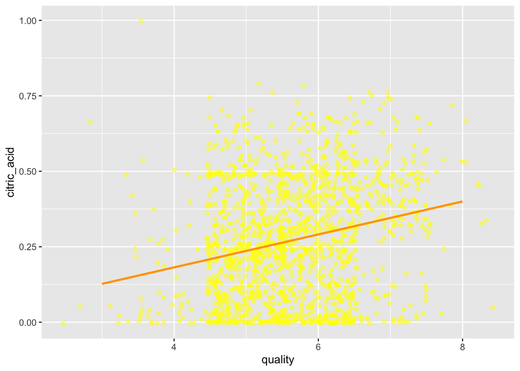

```r
ggplot(wineqc, aes(quality, citric_acid)) +
  geom_jitter(width = 0.55, alpha = 0.5, colour = "yellow") +
  geom_smooth(method=lm, se=FALSE, colour = "orange")
```

```r
#the affect citric acid has on the quality.
```

the affect citric acid has on the quality.